# Subjective hearing loss

[back to Home page |](https://github.com/huiwen-goy/C2-multidomain) [back to Analyses page |](https://huiwen-goy.github.io/C2-multidomain/C2-11Analyses.html) [Data quality |](https://huiwen-goy.github.io/C2-multidomain/C2-1Quality.html)

[Demographics |](https://huiwen-goy.github.io/C2-multidomain/C2-2Demographic.html) [Physical health |](https://huiwen-goy.github.io/C2-multidomain/C2-3Physical.html) [Hearing |](https://huiwen-goy.github.io/C2-multidomain/C2-4Hearing.html) [Cognition |](https://huiwen-goy.github.io/C2-multidomain/C2-5Cognition.html) [Mobility and balance |](https://huiwen-goy.github.io/C2-multidomain/C2-6Mobility.html) [Quality of life |](https://huiwen-goy.github.io/C2-multidomain/C2-7QoL.html) [Mental health |](https://huiwen-goy.github.io/C2-multidomain/C2-8Mental.html) [Social participation and support |](https://huiwen-goy.github.io/C2-multidomain/C2-9Social.html) [Views on hearing loss |](https://huiwen-goy.github.io/C2-multidomain/C2-10Views.html) [back to Analyses page](https://huiwen-goy.github.io/C2-multidomain/C2-11Analyses.html)

# Three different measures

• Subjective hearing loss: Do you have a hearing loss? Yes, No  
• Subjective hearing rating: Is your hearing, using a HA if you use one… Poor to Excellent  
• Subjective hearing rating: Is your hearing, without a HA… Poor to Excellent

**Correlations and missing data**

```
## Subj hearing loss
##    1    2 <NA>
## 62.0 30.2  7.8
```

```
## Subj hearing aided
##    1    2    3    4    5 <NA>
##  1.5  7.6 21.3 22.4 15.2 32.1
```

```
## Subj hearing no aids
##    1    2    3    4    5 <NA>
##  1.9 27.3 36.4 21.8 10.1  2.5
```

# Relationship between BPTA & subjective hearing loss

back to top

**Correlations and plot**

```
##                      subj_hear_1_loss_bin Subj_hear_5_rate Subj_hear_6_no_aids
## subj_hear_1_loss_bin            1.0000000       -0.3374524          -0.6753531
## Subj_hear_5_rate               -0.3374524        1.0000000           0.5768517
## Subj_hear_6_no_aids            -0.6753531        0.5768517           1.0000000
```

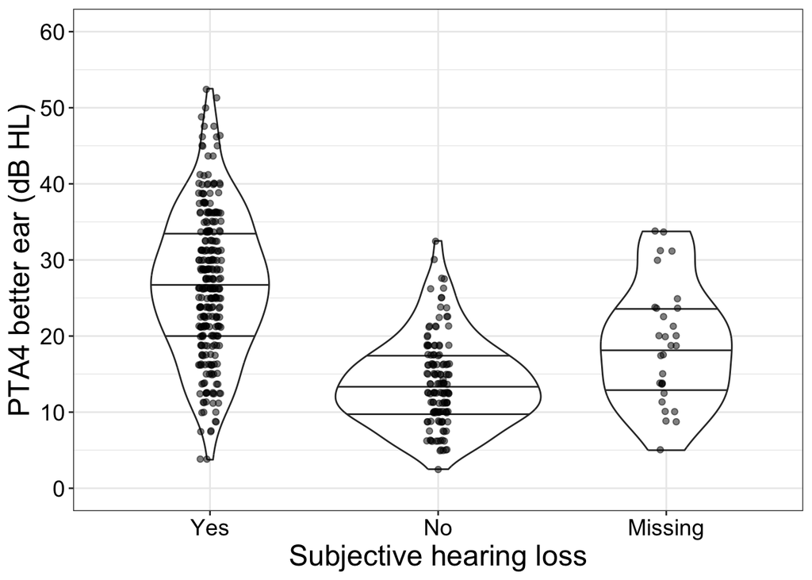

# Regression (following Hamalainen et al 2021)

back to top

With 18 variables, participants are more likely to report subjective hearing loss if they:  
• have a higher BPTA4 (13.8 vs 26.4)  
• have greater PTA4 asymmetry (3.0 vs 7.2)  
• have more difficulty understanding speech in noise (SSQ speech; 8.0 vs 6.5)

**Output: Regression**

```
##
## Call:
## glm(formula = m_H_formula, family = "binomial", data = compdata_H)
##
## Coefficients:
##                          Estimate Std. Error z value       Pr(>|z|)
## (Intercept)              -3.44062    2.39126  -1.439        0.15020
## PTA4_better_ear           0.18795    0.02966   6.337 0.000000000234 ***
## PTA4_asym                 0.14074    0.05269   2.671        0.00756 **
## any_hearing_device       17.46485  935.68539   0.019        0.98511
## SSQ15i_speech            -0.39307    0.10059  -3.908 0.000093201385 ***
## vision_difficulty        -1.24126    1.12068  -1.108        0.26804
## Age                       0.02706    0.03071   0.881        0.37811
## Gender_rec                0.53161    0.41324   1.286        0.19830
## Enough_money              0.02346    0.22283   0.105        0.91614
## Multimorbidity_score      0.11119    0.10044   1.107        0.26827
## positive_SCI             -0.24793    0.73082  -0.339        0.73442
## Transport_problem        -1.64529    0.90011  -1.828        0.06757 .
## Retired                  -0.52305    0.42424  -1.233        0.21761
## Lives_alone               0.93837    0.50239   1.868        0.06179 .
## Lonely                   -0.25911    0.52804  -0.491        0.62364
## Soc_support               0.20417    0.25891   0.789        0.43036
## Social_network_index      0.25748    0.14317   1.798        0.07210 .
## Soc_participation_freq   -0.34048    0.32996  -1.032        0.30213
## Soc_participation_types  -0.13352    0.15347  -0.870        0.38428
## ---
## Signif. codes:  0 '***' 0.001 '**' 0.01 '*' 0.05 '.' 0.1 ' ' 1
##
## (Dispersion parameter for binomial family taken to be 1)
##
##     Null deviance: 450.09  on 364  degrees of freedom
## Residual deviance: 215.47  on 346  degrees of freedom
## AIC: 253.47
##
## Number of Fisher Scoring iterations: 18
```

With variable selection, participants are more likely to report subjective hearing loss if they:  
• have a higher BPTA4  
• have more difficulty understanding speech in noise  
• have any hearing device (?; 0% vs 34%)  
• have greater PTA4 asymmetry

**Output: Lasso**

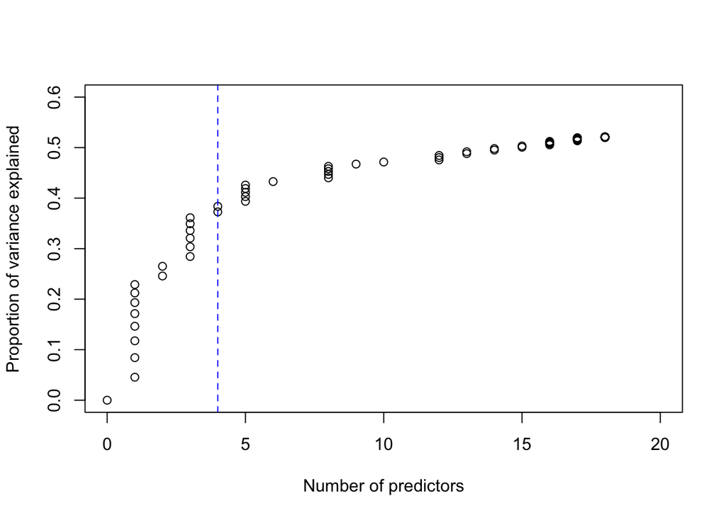

```
## 19 x 1 sparse Matrix of class "dgCMatrix"
##                                  s1
## (Intercept)             -0.48191328
## PTA4_better_ear          0.11661075
## PTA4_asym                0.00335294
## any_hearing_device       0.77984219
## SSQ15i_speech           -0.16741673
## vision_difficulty        .
## Age                      .
## Gender_rec               .
## Enough_money             .
## Multimorbidity_score     .
## positive_SCI             .
## Transport_problem        .
## Retired                  .
## Lives_alone              .
## Lonely                   .
## Soc_support              .
## Social_network_index     .
## Soc_participation_freq   .
## Soc_participation_types  .
```

```
##
## Call:
## glm(formula = subj_hear_1_loss_bin ~ PTA4_better_ear + SSQ15i_speech +
##     any_hearing_device + PTA4_asym, family = "binomial", data = compdata_H)
##
## Coefficients:
##                     Estimate Std. Error z value Pr(>|z|)
## (Intercept)         -1.05315    0.83159  -1.266  0.20536
## PTA4_better_ear      0.18464    0.02574   7.174 7.28e-13 ***
## SSQ15i_speech       -0.34983    0.08656  -4.041 5.31e-05 ***
## any_hearing_device  17.43543  966.48790   0.018  0.98561
## PTA4_asym            0.15049    0.05003   3.008  0.00263 **
## ---
## Signif. codes:  0 '***' 0.001 '**' 0.01 '*' 0.05 '.' 0.1 ' ' 1
##
## (Dispersion parameter for binomial family taken to be 1)
##
##     Null deviance: 450.09  on 364  degrees of freedom
## Residual deviance: 231.59  on 360  degrees of freedom
## AIC: 241.59
##
## Number of Fisher Scoring iterations: 18
```

```
##                       OddsRatio 2.5 %        97.5 %
## (Intercept)               0.349 0.068  1.795000e+00
## PTA4_better_ear           1.203 1.147  1.269000e+00
## SSQ15i_speech             0.705 0.590  8.300000e-01
## any_hearing_device 37334558.389 0.000 5.264766e+160
## PTA4_asym                 1.162 1.062  1.293000e+00
```

**Group comparisons and correlations**

```
##
##  Welch Two Sample t-test
##
## data:  compdata_H$PTA4_better_ear[compdata_H$subj_hear_1_loss_bin == 0] and compdata_H$PTA4_better_ear[compdata_H$subj_hear_1_loss_bin == 1]
## t = -16.08, df = 334.7, p-value < 2.2e-16
## alternative hypothesis: true difference in means is not equal to 0
## 95 percent confidence interval:
##  -14.08882 -11.01756
## sample estimates:
## mean of x mean of y
##  13.85491  26.40810
```

```
##
##  Welch Two Sample t-test
##
## data:  compdata_H$PTA4_asym[compdata_H$subj_hear_1_loss_bin == 0] and compdata_H$PTA4_asym[compdata_H$subj_hear_1_loss_bin == 1]
## t = -4.7925, df = 293.89, p-value = 0.000002619
## alternative hypothesis: true difference in means is not equal to 0
## 95 percent confidence interval:
##  -5.974736 -2.496131
## sample estimates:
## mean of x mean of y
##  2.997768  7.233202
```

```
##
##  Welch Two Sample t-test
##
## data:  compdata_H$SSQ15i_speech[compdata_H$subj_hear_1_loss_bin == 0] and compdata_H$SSQ15i_speech[compdata_H$subj_hear_1_loss_bin == 1]
## t = 6.8625, df = 246.35, p-value = 5.449e-11
## alternative hypothesis: true difference in means is not equal to 0
## 95 percent confidence interval:
##  1.098510 1.982923
## sample estimates:
## mean of x mean of y
##  7.994985  6.454269
```

```
##           Subj HL
## Any device    0    1
##          0 1.00 0.66
##          1 0.00 0.34
```

```
##                 Subj HL
## Subj Cogn Impair    0    1
##                0 0.95 0.89
##                1 0.05 0.11
```

```
##                 PTA4_better_ear    PTA4_asym SSQ15i_speech
## PTA4_better_ear     1.000000000  0.006666159    -0.1903212
## PTA4_asym           0.006666159  1.000000000    -0.2207040
## SSQ15i_speech      -0.190321238 -0.220704016     1.0000000
```

Compared with Hamalainen et al (2021)’s results:  
• Similarities: Worse PTA, higher asymmetry, more trouble hearing in noise  
• They found these effects, but we did not (or found weak effects): Age, male sex, device use, higher multimorbidity, better memory (higher PC scores), driving/good transport, social network index

# Regression (our variables; overall scores)

back to top

With 24 variables, participants are more likely to report subjective hearing loss if they:  
• have worse BPTA4 (14.1 vs 26.5)  
• have more PTA asymmetry (2.9 vs 7.3)  
• have worse overall SSQ scores (8.9 vs 7.6)  
• have worse HHIE total scores (4.1 vs 13.2)  
• have experienced tinnitus in the past week (15% vs 39%)

**Output: Regression**

```
##
## Call:
## glm(formula = m_overall_formula, family = "binomial", data = compdata_overall)
##
## Coefficients:
##                           Estimate Std. Error z value       Pr(>|z|)
## (Intercept)             -2.7880684  4.5428472  -0.614       0.539396
## Age                      0.0274458  0.0315105   0.871       0.383750
## Gender_rec               0.0119494  0.4392064   0.027       0.978295
## Retired                 -0.1671280  0.4187755  -0.399       0.689829
## Phys_1_rate              0.0291199  0.3047359   0.096       0.923872
## Multimorbidity_score     0.0559126  0.1056201   0.529       0.596546
## vision_difficulty       -0.6459741  1.3478165  -0.479       0.631743
## ABC_mean                 0.0250846  0.0226103   1.109       0.267243
## PTA4_better_ear          0.1891058  0.0294947   6.412 0.000000000144 ***
## PTA4_asym                0.1684993  0.0555489   3.033       0.002419 **
## SSQ15i_mean             -0.4113519  0.1994349  -2.063       0.039152 *
## HHIES_total              0.1507278  0.0409768   3.678       0.000235 ***
## SIM_mean                -0.0007735  0.0933039  -0.008       0.993386
## Emocheq4_mean           -0.3688000  0.2833834  -1.301       0.193116
## Tinnitus_pastwk          1.3014420  0.4215639   3.087       0.002021 **
## positive_SCI            -0.6635185  0.7365727  -0.901       0.367685
## CSRQ_mean               -0.1301333  0.5878862  -0.221       0.824814
## WHOQOL_overall_qol      -0.6119985  0.4175709  -1.466       0.142753
## WHOQOL_health_qol       -0.0300999  0.2773344  -0.109       0.913573
## SWLS_average             0.1383754  0.2119492   0.653       0.513840
## Lonely                  -0.9180244  0.5886563  -1.560       0.118872
## Social_network_index     0.1324665  0.1427077   0.928       0.353285
## Soc_participation_freq  -0.2317947  0.3300053  -0.702       0.482432
## Soc_participation_types -0.0385387  0.1482556  -0.260       0.794904
## Soc_support              0.0588845  0.2575265   0.229       0.819138
## ---
## Signif. codes:  0 '***' 0.001 '**' 0.01 '*' 0.05 '.' 0.1 ' ' 1
##
## (Dispersion parameter for binomial family taken to be 1)
##
##     Null deviance: 472.17  on 371  degrees of freedom
## Residual deviance: 216.80  on 347  degrees of freedom
## AIC: 266.8
##
## Number of Fisher Scoring iterations: 7
```

With variable selection, participants are more likely to report subjective hearing loss if they:  
• have worse BPTA4  
• have more PTA asymmetry  
• have worse overall SSQ scores  
• have worse HHIE total scores  
• have experienced tinnitus in the past week

**Output: Lasso**

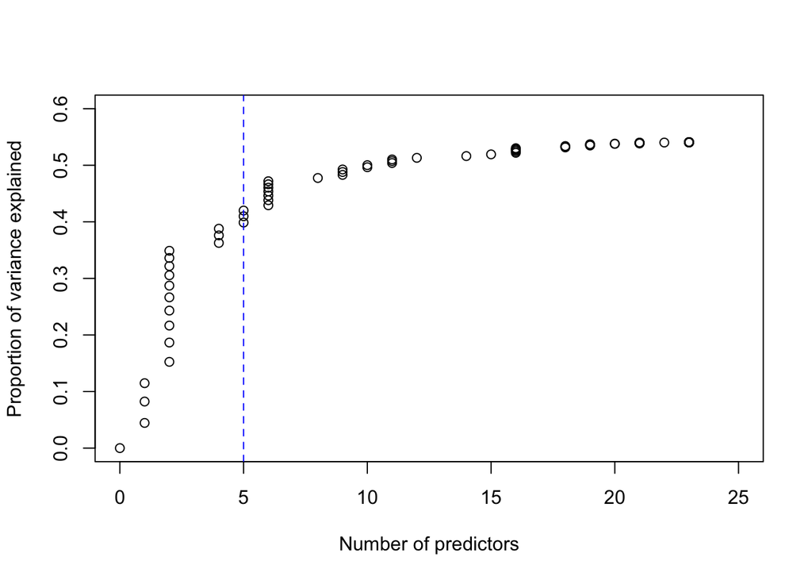

```
## 25 x 1 sparse Matrix of class "dgCMatrix"
##                                    s1
## (Intercept)             -1.6447762177
## Age                      .
## Gender_rec               .
## Retired                  .
## Phys_1_rate              .
## Multimorbidity_score     .
## vision_difficulty        .
## ABC_mean                 .
## PTA4_better_ear          0.0994712612
## PTA4_asym                0.0001265572
## SSQ15i_mean             -0.0406399974
## HHIES_total              0.0689201944
## SIM_mean                 .
## Emocheq4_mean            .
## Tinnitus_pastwk          0.1959237029
## positive_SCI             .
## CSRQ_mean                .
## WHOQOL_overall_qol       .
## WHOQOL_health_qol        .
## SWLS_average             .
## Lonely                   .
## Social_network_index     .
## Soc_participation_freq   .
## Soc_participation_types  .
## Soc_support              .
```

```
##
## Call:
## glm(formula = subj_hear_1_loss_bin ~ PTA4_better_ear + PTA4_asym +
##     SSQ15i_mean + HHIES_total + Tinnitus_pastwk, family = "binomial",
##     data = compdata_overall)
##
## Coefficients:
##                 Estimate Std. Error z value Pr(>|z|)
## (Intercept)     -2.35004    1.54229  -1.524 0.127576
## PTA4_better_ear  0.18701    0.02416   7.740 9.94e-15 ***
## PTA4_asym        0.17021    0.05113   3.329 0.000871 ***
## SSQ15i_mean     -0.28547    0.16263  -1.755 0.079203 .
## HHIES_total      0.10048    0.03032   3.314 0.000921 ***
## Tinnitus_pastwk  1.19970    0.39294   3.053 0.002265 **
## ---
## Signif. codes:  0 '***' 0.001 '**' 0.01 '*' 0.05 '.' 0.1 ' ' 1
##
## (Dispersion parameter for binomial family taken to be 1)
##
##     Null deviance: 472.17  on 371  degrees of freedom
## Residual deviance: 231.92  on 366  degrees of freedom
## AIC: 243.92
##
## Number of Fisher Scoring iterations: 7
```

```
##                 OddsRatio 2.5 % 97.5 %
## (Intercept)         0.095 0.005  2.023
## PTA4_better_ear     1.206 1.153  1.268
## PTA4_asym           1.186 1.083  1.323
## SSQ15i_mean         0.752 0.541  1.026
## HHIES_total         1.106 1.044  1.176
## Tinnitus_pastwk     3.319 1.563  7.340
```

**Group comparisons and correlations**

```
##
##  Welch Two Sample t-test
##
## data:  compdata_overall$PTA4_better_ear[compdata_overall$subj_hear_1_loss_bin == 0] and compdata_overall$PTA4_better_ear[compdata_overall$subj_hear_1_loss_bin == 1]
## t = -15.739, df = 352.2, p-value < 2.2e-16
## alternative hypothesis: true difference in means is not equal to 0
## 95 percent confidence interval:
##  -13.96291 -10.86097
## sample estimates:
## mean of x mean of y
##  14.05894  26.47088
```

```
##
##  Welch Two Sample t-test
##
## data:  compdata_overall$PTA4_asym[compdata_overall$subj_hear_1_loss_bin == 0] and compdata_overall$PTA4_asym[compdata_overall$subj_hear_1_loss_bin == 1]
## t = -4.9406, df = 283.11, p-value = 0.000001334
## alternative hypothesis: true difference in means is not equal to 0
## 95 percent confidence interval:
##  -6.190415 -2.663096
## sample estimates:
## mean of x mean of y
##  2.912602  7.339357
```

```
##
##  Welch Two Sample t-test
##
## data:  compdata_overall$SSQ15i_mean[compdata_overall$subj_hear_1_loss_bin == 0] and compdata_overall$SSQ15i_mean[compdata_overall$subj_hear_1_loss_bin == 1]
## t = 8.7695, df = 359.99, p-value < 2.2e-16
## alternative hypothesis: true difference in means is not equal to 0
## 95 percent confidence interval:
##  0.9532842 1.5044315
## sample estimates:
## mean of x mean of y
##  8.873249  7.644391
```

```
##
##  Welch Two Sample t-test
##
## data:  compdata_overall$HHIES_total[compdata_overall$subj_hear_1_loss_bin == 0] and compdata_overall$HHIES_total[compdata_overall$subj_hear_1_loss_bin == 1]
## t = -12.26, df = 334.24, p-value < 2.2e-16
## alternative hypothesis: true difference in means is not equal to 0
## 95 percent confidence interval:
##  -10.615574  -7.680048
## sample estimates:
## mean of x mean of y
##  4.065041 13.212851
```

```
##                 Subj HL
## Tinnitus past wk    0    1
##                0 0.85 0.61
##                1 0.15 0.39
```

```
##                 PTA4_better_ear   PTA4_asym SSQ15i_mean HHIES_total
## PTA4_better_ear      1.00000000  0.00992157  -0.2216142   0.4138355
## PTA4_asym            0.00992157  1.00000000  -0.2625668   0.1988174
## SSQ15i_mean         -0.22161422 -0.26256678   1.0000000  -0.6021376
## HHIES_total          0.41383553  0.19881738  -0.6021376   1.0000000
```

# Regression (our variables; subscores)

back to top

With 29 variables, participants are more likely to report experiencing subjective hearing loss if they:  
• have worse BPTA4 (14.0 vs 26.2)  
• have more PTA asymmetry (2.8 vs 7.5)  
• have experienced tinnitus in the past week (17% vs 37%)

**Output: Regression**

```
##
## Call:
## glm(formula = m_sub_formula, family = "binomial", data = compdata_sub)
##
## Coefficients:
##                          Estimate Std. Error z value     Pr(>|z|)
## (Intercept)              1.686129   5.251314   0.321      0.74814
## Age                      0.032910   0.035120   0.937      0.34872
## Gender_rec               0.464956   0.467230   0.995      0.31967
## Retired                 -0.473995   0.479151  -0.989      0.32255
## Phys_1_rate              0.255264   0.315096   0.810      0.41787
## Multimorbidity_score     0.008797   0.118729   0.074      0.94094
## vision_difficulty       -0.818410   1.397829  -0.585      0.55822
## ABC_mean                 0.022509   0.026843   0.839      0.40173
## PTA4_better_ear          0.183893   0.032188   5.713 0.0000000111 ***
## PTA4_asym                0.173084   0.063815   2.712      0.00668 **
## SSQ15i_speech           -0.059343   0.173313  -0.342      0.73205
## SSQ15i_spatial           0.034098   0.241934   0.141      0.88792
## SSQ15i_qualities        -0.517043   0.291573  -1.773      0.07618 .
## HHIES_soc                0.140160   0.086771   1.615      0.10625
## HHIES_emo                0.142107   0.089560   1.587      0.11257
## SIM_mean                 0.017668   0.106951   0.165      0.86879
## Emocheq4_mean           -0.232516   0.303123  -0.767      0.44304
## Tinnitus_pastwk          1.055605   0.441472   2.391      0.01680 *
## positive_SCI            -0.721619   0.817037  -0.883      0.37712
## CSRQ_mean               -0.745548   0.668766  -1.115      0.26493
## WHOQOL_dom1_phys        -0.227425   0.154728  -1.470      0.14161
## WHOQOL_dom2_psy         -0.233911   0.197032  -1.187      0.23516
## WHOQOL_dom3_soc          0.018529   0.106446   0.174      0.86181
## WHOQOL_dom4_env          0.136180   0.162369   0.839      0.40164
## SWLS_average             0.036551   0.231115   0.158      0.87434
## Lonely                  -0.583329   0.596081  -0.979      0.32777
## Social_network_index     0.179939   0.158990   1.132      0.25773
## Soc_participation_freq  -0.280730   0.355436  -0.790      0.42963
## Soc_participation_types  0.033720   0.160386   0.210      0.83348
## Soc_support             -0.048100   0.311211  -0.155      0.87717
## ---
## Signif. codes:  0 '***' 0.001 '**' 0.01 '*' 0.05 '.' 0.1 ' ' 1
##
## (Dispersion parameter for binomial family taken to be 1)
##
##     Null deviance: 422.76  on 338  degrees of freedom
## Residual deviance: 191.75  on 309  degrees of freedom
## AIC: 251.75
##
## Number of Fisher Scoring iterations: 7
```

With variable selection, participants are more likely to report experiencing subjective hearing loss if they:  
• have worse BPTA4  
• have poorer HHIE-S social subscores (2.9 vs 7.8)

**Output: Lasso**

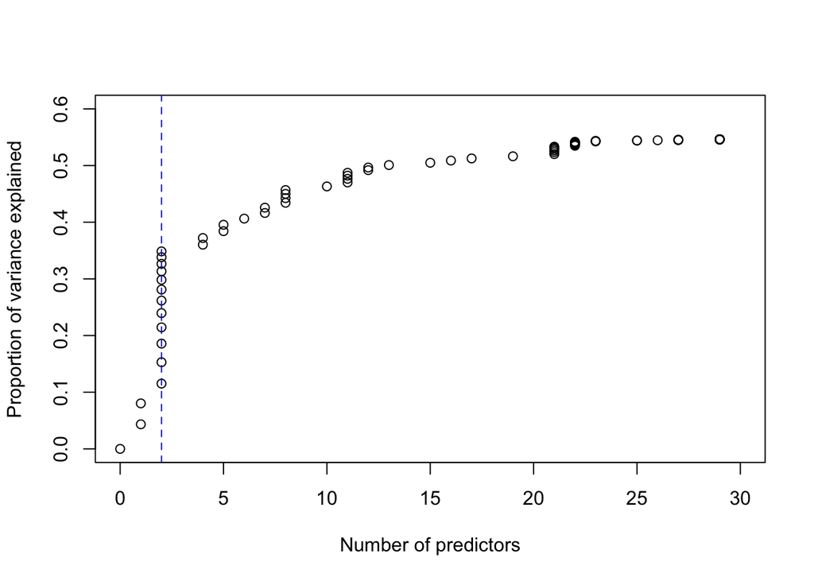

```
## 30 x 1 sparse Matrix of class "dgCMatrix"
##                                  s1
## (Intercept)             -1.55040997
## Age                      .
## Gender_rec               .
## Retired                  .
## Phys_1_rate              .
## Multimorbidity_score     .
## vision_difficulty        .
## ABC_mean                 .
## PTA4_better_ear          0.08371127
## PTA4_asym                .
## SSQ15i_speech            .
## SSQ15i_spatial           .
## SSQ15i_qualities         .
## HHIES_soc                0.10892272
## HHIES_emo                .
## SIM_mean                 .
## Emocheq4_mean            .
## Tinnitus_pastwk          .
## positive_SCI             .
## CSRQ_mean                .
## WHOQOL_dom1_phys         .
## WHOQOL_dom2_psy          .
## WHOQOL_dom3_soc          .
## WHOQOL_dom4_env          .
## SWLS_average             .
## Lonely                   .
## Social_network_index     .
## Soc_participation_freq   .
## Soc_participation_types  .
## Soc_support              .
```

```
##
## Call:
## glm(formula = subj_hear_1_loss_bin ~ PTA4_better_ear + HHIES_soc,
##     family = "binomial", data = compdata_sub)
##
## Coefficients:
##                 Estimate Std. Error z value Pr(>|z|)
## (Intercept)     -3.70927    0.47187  -7.861 3.82e-15 ***
## PTA4_better_ear  0.16564    0.02334   7.097 1.28e-12 ***
## HHIES_soc        0.25558    0.04533   5.639 1.71e-08 ***
## ---
## Signif. codes:  0 '***' 0.001 '**' 0.01 '*' 0.05 '.' 0.1 ' ' 1
##
## (Dispersion parameter for binomial family taken to be 1)
##
##     Null deviance: 422.76  on 338  degrees of freedom
## Residual deviance: 247.12  on 336  degrees of freedom
## AIC: 253.12
##
## Number of Fisher Scoring iterations: 6
```

```
##                 OddsRatio 2.5 % 97.5 %
## (Intercept)         0.024 0.009  0.059
## PTA4_better_ear     1.180 1.130  1.239
## HHIES_soc           1.291 1.186  1.418
```

**Group comparisons and correlations**

```
##
##  Welch Two Sample t-test
##
## data:  compdata_sub$PTA4_better_ear[compdata_sub$subj_hear_1_loss_bin == 0] and compdata_sub$PTA4_better_ear[compdata_sub$subj_hear_1_loss_bin == 1]
## t = -14.959, df = 317.96, p-value < 2.2e-16
## alternative hypothesis: true difference in means is not equal to 0
## 95 percent confidence interval:
##  -13.73538 -10.54223
## sample estimates:
## mean of x mean of y
##  14.03037  26.16918
```

```
##
##  Welch Two Sample t-test
##
## data:  compdata_sub$PTA4_asym[compdata_sub$subj_hear_1_loss_bin == 0] and compdata_sub$PTA4_asym[compdata_sub$subj_hear_1_loss_bin == 1]
## t = -4.9369, df = 262.7, p-value = 0.000001412
## alternative hypothesis: true difference in means is not equal to 0
## 95 percent confidence interval:
##  -6.574322 -2.825351
## sample estimates:
## mean of x mean of y
##  2.827103  7.526940
```

```
##                 Subj HL
## Tinnitus past wk    0    1
##                0 0.83 0.63
##                1 0.17 0.37
```

```
##
##  Welch Two Sample t-test
##
## data:  compdata_sub$HHIES_soc[compdata_sub$subj_hear_1_loss_bin == 0] and compdata_sub$HHIES_soc[compdata_sub$subj_hear_1_loss_bin == 1]
## t = -11.308, df = 260.23, p-value < 2.2e-16
## alternative hypothesis: true difference in means is not equal to 0
## 95 percent confidence interval:
##  -5.704538 -4.012510
## sample estimates:
## mean of x mean of y
##  2.934579  7.793103
```

```
##                 PTA4_better_ear  PTA4_asym HHIES_soc
## PTA4_better_ear      1.00000000 0.01304644 0.4221395
## PTA4_asym            0.01304644 1.00000000 0.2116351
## HHIES_soc            0.42213954 0.21163511 1.0000000
```